# Análisis de secuencias de lectura corta con DADA2

## Instalando y llamando la paquetería

Primero se procede a instalar la paquetería para la versión de RStudio correspondiente.

```r
if (!requireNamespace("BiocManager", quietly = TRUE))
    install.packages("BiocManager")
BiocManager::install("dada2", version = "3.14") #Ajustar versión en caso de que haya sido actualizada
```

Se llama a la paquetería para poder trabajar con sus funciones.

```r
library(dada2); packageVersion("dada2")
```

## Definiendo directorio

Una vez que se tenga una carpeta con las secuencias a analizar, se nombra una variable con la ruta de los archivos.

```r
path<-"/Users/adriantorres/Desktop/UNIVERSIDAD/SERVICIO/secuencias" #Cambiar por ruta de la carpeta con los archivos
setwd(path) #Este comando hará que todas las carpetas y archivos creados estén dentro de la carpeta en la que estamos trabajando
list.files(path)
```

Una vez obtenidos los archivos, se deben filtrar y manipular para obtener listas de las lecturas frontales (*fnFs*) y de reversa (*fnRs*).

```r
#Adecuar pattern según el nombre de los archivos
fnFs <- sort(list.files(path, pattern="_R1_001.fastq", full.names = TRUE))
fnRs <- sort(list.files(path, pattern="_R2_001.fastq", full.names = TRUE))
#Se hace un recorte para obtener sólo los identificadores de las secuencias
sample.names <- sapply(strsplit(basename(fnFs), "_"), `[`, 1)
```

> <sub>Prestar atención al patrón en los nombres de los archivos, ya que de no ser correctos dará como resultado objetos vacíos.</sub>

## Inspeccionar perfiles de calidad en las lecturas

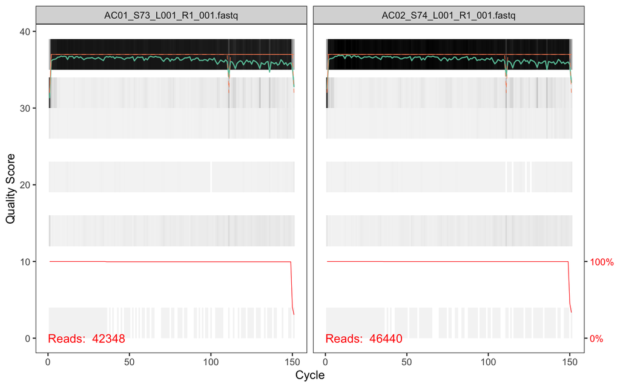

```r
plotQualityProfile(fnFs[1:2])
```

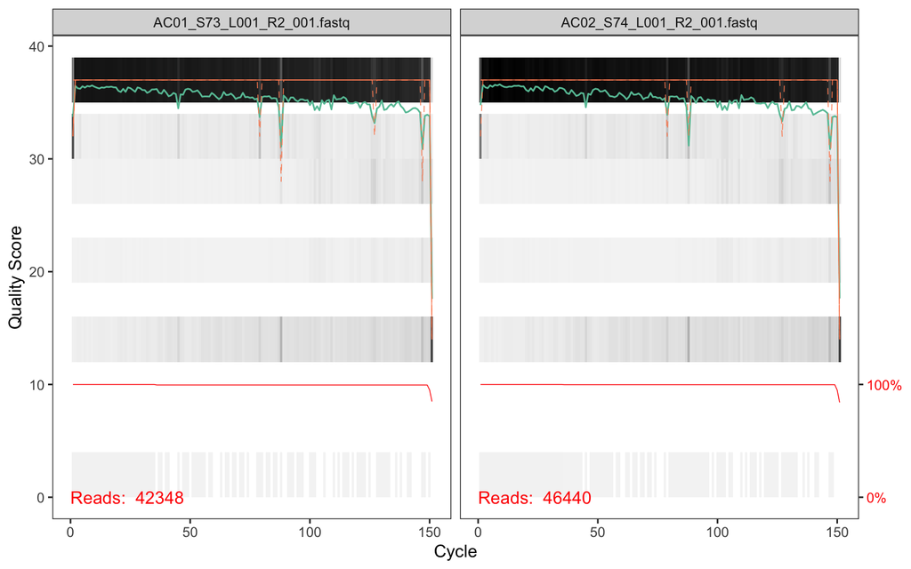

```r
plotQualityProfile(fnRs[1:2])
```

```r
#En la figura, Reads representa el número n de muestras leídas, por default la función usa 500,000 muestras, se puede modificar agregando a la línea de código n= número deseado. Un ejemplo a continuación
# plotQualityProfile(fnFs[1:2], n=10000)
```

(*Opcional*) se puede realizar el agregado de todas las muestras usando el siguiente código.

```r
plotQualityProfile(fnFs, aggregate = TRUE)
plotQualityProfile(fnRs, aggregate = TRUE)
```

Una vez se identifiquen las posiciones en las que la calidad sea menor a 30, tanto en las lecturas frontales y de reversa, se procede a realizar el corte.

## Corte y filtrado

Se crea una carpeta dentro del directorio de trabajo para almacenar las secuencias filtradas en formato *fastq.gz*.

```r
filtFs <- file.path(path, "filtered", paste0(sample.names, "_F_filt.fastq.gz"))
filtRs <- file.path(path, "filtered", paste0(sample.names, "_R_filt.fastq.gz"))
```

> <sub>Recuerda que el objeto *path* contiene la ruta donde se encuentran tus secuencias iniciales.</sub>

Una primera aproximación para realizar el corte es utilizar los parámetros predeterminados de *dada2*.

```r
out <- filterAndTrim(fnFs, filtFs, fnRs, filtRs, truncLen=c(150,150),
                     maxN=0, maxEE = c(2,2), truncQ=2, rm.phix=TRUE,
                     compress=TRUE, multithread=TRUE) # En Windows es multithread=FALSE
head(out)
```

En instancias donde el resultado obtenido sea de 0 alineaciones, se pueden relajar los parámetros en el filtrado para una menor restricción.

> <sub>Para ver a qué corresponde cada parámetro, consultar la [documentación](https://www.bioconductor.org/packages/devel/bioc/manuals/dada2/man/dada2.pdf) de dada2.</sub>

## Tasa de errores

Para conocer la tasa de errores por sustitución en las secuencias el paquete *dada2* contiene funciones que permiten modelar los errores paramétricos.

```r
errF <- learnErrors(filtFs, multithread=TRUE)
errR <- learnErrors(filtRs, multithread=TRUE)
```

Para visualizar los errores estimados se grafican los resultados.

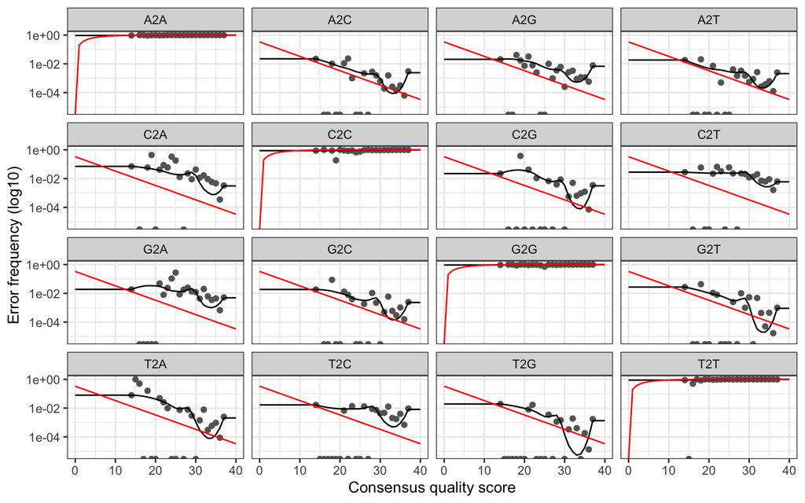

```r
plotErrors(errF, nominalQ=TRUE)
```

> <sub>La línea negra corresponde a los errores estimados, mientras que la línea roja corresponde a errores esperados. Deben tener una tendencia similar.</sub>

## Derreplicación

Se combinan todas las lecturas de secuenciación idénticas en “secuencias únicas”. Este proceso reduce sustancialmente el tiempo de cálculo al eliminar las comparaciones redundantes.

```r
derepFs <- derepFastq(filtFs, verbose=TRUE)
derepRs <- derepFastq(filtRs, verbose=TRUE)
names(derepFs) <- sample.names
names(derepRs) <- sample.names
```

## Inferencia de muestreo

Para obtener las variantes de las secuencias únicas sometidas a análisis se corren las siguientes líneas de código.

```r
dadaFs <- dada(derepFs, err=errF, multithread=TRUE)
dadaRs <- dada(derepRs, err=errR, multithread=TRUE)
```

## Combinar secuencias emparejadas

Se combinan las lecturas frontales y de reversa para obtener las secuencias filtradas completas.

```r
mergers <- mergePairs(dadaFs, derepFs, dadaRs, derepRs, verbose=TRUE)
#Si quieres visualizar los resultados de la primera muestra utiliza 'head(mergers[[1]])'
```

> <sub>Las secuencias combinadas sólo se muestran si las lecturas frontrales y de reversa se superponen en al menos 12 bases, siendo idénticas entre sí.</sub>

## Construir tabla de secuencias

Para una mejor visualización de los emparejamientos que encontró el programa, se realiza una tabla con las secuencias alineadas.

```r
seqtab <- makeSequenceTable(mergers)
#Las siguientes líneas de código son para inspeccionar la tabla
dim(seqtab)
table(nchar(getSequences(seqtab)))
```

## Remover quimeras

Con el procesamiento previo se asegura la eliminación de los errores de sustitución o de indel, pero las químeras persisten. Para eliminarlas la paquetería contiene funciones integradas que son de utilidad.

```r
seqtab.nochim <- removeBimeraDenovo(seqtab, method="consensus", multithread=TRUE, verbose=TRUE)
dim(seqtab.nochim)
sum(seqtab.nochim)/sum(seqtab)
```

> <sub>Si la mayoría de las secuencias son eliminadas tras remover las químeras el procesamiento previo debe ser revisado.</sub>

## Seguimiento de las lecturas a través del procesamiento

Para saber cuantas secuencias fueron filtradas cada paso en el flujo del proceso se corren las siguientes líneas.

```r
getN <- function(x) sum(getUniques(x))
track <- cbind(out, sapply(dadaFs, getN), sapply(dadaRs, getN), sapply(mergers, getN), rowSums(seqtab.nochim))
colnames(track) <- c("input", "filtered", "denoisedF", "denoisedR", "merged", "nonchim")
rownames(track) <- sample.names
head(track)
```

## Asignar taxonomía

Usando un archivo de referencia con taxonomías asignadas, se corren las siguientes líneas de código para conocer la taxonomía de las secuencias analizadas.

```r
taxa <- assignTaxonomy(seqtab.nochim, "/Users/adriantorres/Desktop/UNIVERSIDAD/SERVICIO/silva_nr99_v138.1_train_set.fa", multithread=TRUE) #Cambiar la ruta del archivo a donde se tenga guardado
```

Adicionalmente, se pueden asignar las especies de las secuencias analizadas.

```r
taxa <- addSpecies(taxa, "/Users/adriantorres/Desktop/UNIVERSIDAD/SERVICIO/silva_species_assignment_v138.1.fa")
```

Por último inspeccionamos los resultados obtenidos de las asignaciones

```r
taxa.print <- taxa
rownames(taxa.print) <- NULL
head(taxa.print)
```

## Exportar tablas de ASVs

```r
#Primero se procede a darles nombres reconocibles
asv_seqs <- colnames(seqtab.nochim)
asv_headers <- vector(dim(seqtab.nochim)[2], mode="character")
for (i in 1:dim(seqtab.nochim)[2]) {
  asv_headers[i] <- paste(">ASV", i, sep="_")
}
#Establecer la carpeta donde se van a guardar
path2<-file.path(path, "Tablas")
dir.create(path2)
#Archivo fasta de ASVs
asv_fasta <- c(rbind(asv_headers, asv_seqs))
write(asv_fasta, file.path(path2, "ASVs.fa"))
#Archivo csv de abundancias
asv_tab <- t(seqtab.nochim)
row.names(asv_tab) <- sub(">", "", asv_headers)
write.table(asv_tab, file.path(path2,"ASVs_counts_silva.csv"), sep="\t", quote=F, col.names=NA)
#Archivo csv de taxonomias
asv_tax <- taxa
row.names(asv_tax) <- sub(">", "", asv_headers)
write.table(asv_tax, file.path(path2,"ASVs_taxonomy_silva.csv"), sep="\t", quote=F, col.names=NA)
#Archivo csv de taxonfile.path()s abundancias
asv_total <- merge(asv_tab,asv_tax,by="row.names",all.x=TRUE)
write.table(asv_total, file.path(path2,"ASVs_total_silva.csv"), sep="\t", quote=F, col.names=NA)
```